# S2 Activation: Smoothness, Spectral Leakage, and Equivariance

This report systematically studies the chain:

$$\text{Activation Smoothness} \;\rightarrow\; \text{Spectral Leakage} \;\rightarrow\; \text{Equivariance Error} \;\rightarrow\; \text{Task Performance}$$

**S2 Activation** is the standard nonlinearity used in SO(3)-equivariant neural networks (SCN, eSCN, EquiformerV2, etc.). It works by:

1. Projecting spherical harmonic (SH) coefficients onto the sphere
2. Applying a pointwise nonlinearity
3. Projecting back to SH coefficients via quadrature

The nonlinearity generates high-frequency components beyond $l_{\max}$, which are lost upon truncation. With insufficient quadrature resolution, these components also **alias** into the low-$l$ coefficients, breaking equivariance.

## Experiments Overview

| Experiment | Question | Key Variable |
| --- | --- | --- |
| **A. Spectral Leakage** | How much energy does each activation spread beyond $l_{\max}$? | Activation function |
| **B. Coefficient Error** | How does sampling resolution affect S2Activation output accuracy? | Activation $\times$ Sampling |
| **C. Equivariance Error** | Does S2Act(D$\cdot$x) = D$\cdot$S2Act(x)? | Activation $\times$ Sampling |
| **D. Task Performance** | Do spectral/equivariance findings predict downstream accuracy? | Activation $\times$ Sampling |

```python
import json
import numpy as np
import matplotlib.pyplot as plt
import matplotlib
from IPython.display import Image, display, Markdown
import pandas as pd

plt.rcParams.update({
    'figure.dpi': 120,
    'font.size': 11,
    'axes.titlesize': 13,
    'axes.labelsize': 11,
})

# Load all results
with open('results/metrics/expA_spectral.json') as f:
    expA = json.load(f)
with open('results/metrics/expB_coefficient_error.json') as f:
    expB = json.load(f)
with open('results/metrics/expC_equivariance.json') as f:
    expC = json.load(f)
with open('results/metrics/expD_task.json') as f:
    expD = json.load(f)

print('All results loaded successfully.')
```

```
All results loaded successfully.
```

## Experiment A: Spectral Leakage Analysis

**Goal**: Measure how different nonlinear activation functions spread energy into spherical harmonic components beyond $l_{\max}$.

**Method**:

- Generate random band-limited input ($l \le l_{\max}$)
- Apply nonlinearity pointwise on the sphere
- Project back using high-resolution GL quadrature ($l_{\max,\text{ref}} = 25$)
- Compute power spectrum $P(l) = \sum_m |c_{lm}|^2$ and leakage ratio $R = \sum_{l > l_{\max}} P(l) / \sum_l P(l)$

**Activations tested**: ReLU, abs, LeakyReLU, SiLU, GELU, tanh, Softplus($\beta$) for $\beta \in \{1, 3, 10, 30, 100\}$, $x^2$, sin

```python
# Table A1: Leakage ratios for all activations
rows = []
for lmax in ['3', '6', '10']:
    for act_name, act_data in expA[lmax].items():
        rows.append({
            'l_max': int(lmax),
            'Activation': act_name,
            'Leakage Ratio R': act_data['leakage_ratio'],
            'R std': act_data['leakage_ratio_std'],
            'l_effective': act_data['l_effective'],
        })

df_A = pd.DataFrame(rows)
# Pivot for cleaner view
pivot_A = df_A.pivot_table(index='Activation', columns='l_max', values='Leakage Ratio R')
pivot_A = pivot_A.sort_values(by=3)  # Sort by l_max=3 leakage

print('Table A1: Leakage Ratio R (fraction of energy above l_max)')
print('=' * 60)
display(pivot_A.style.format('{:.4f}').background_gradient(cmap='RdYlGn_r', axis=None))
```

```
Table A1: Leakage Ratio R (fraction of energy above l_max)
============================================================
```

| l_max Activation | 3 | 6 | 10 |
| --- | --- | --- | --- |
| Softplus_1 | 0.0110 | 0.0337 | 0.0520 |
| tanh | 0.0422 | 0.0946 | 0.1368 |
| Softplus_3 | 0.0560 | 0.0721 | 0.0762 |
| LeakyReLU_0.1 | 0.0716 | 0.0677 | 0.0655 |
| SiLU | 0.0818 | 0.1011 | 0.0977 |
| Softplus_10 | 0.0850 | 0.0832 | 0.0811 |
| Softplus_30 | 0.0898 | 0.0845 | 0.0816 |
| Softplus_100 | 0.0904 | 0.0846 | 0.0817 |
| ReLU | 0.0905 | 0.0846 | 0.0817 |
| sin | 0.0983 | 0.5200 | 0.7892 |
| GELU | 0.1087 | 0.1025 | 0.0923 |
| abs | 0.1540 | 0.1616 | 0.1623 |
| x^2 | 0.2625 | 0.2803 | 0.2768 |

### A1: Power Spectra After Nonlinearity

The plot below shows $P(l)$ for selected activations. The vertical dashed line marks $l_{\max}$. Energy to the right is "leaked" spectral content.

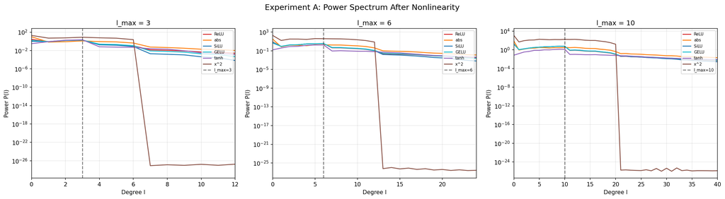

```python
display(Image('results/figures/expA_power_spectra.png', width=900))
```

**Observations**:

### A2: Softplus Family - Continuous Smoothness Control

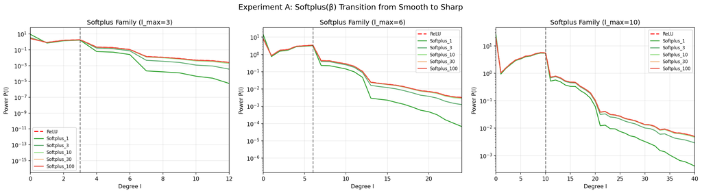

```python
display(Image('results/figures/expA_softplus_spectra.png', width=900))
```

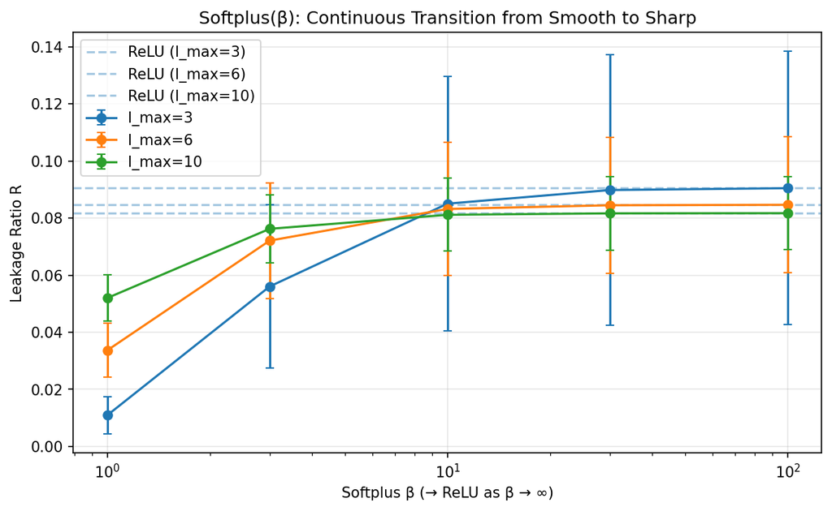

```python
display(Image('results/figures/expA_softplus_transition.png', width=600))
```

**Key finding**: Softplus($\beta$) provides a one-parameter family that smoothly transitions from near-linear (small $\beta$, minimal leakage) to ReLU-like (large $\beta$, maximal leakage). This confirms the theoretical prediction that smoothness controls spectral leakage.

### A3: Leakage Ratio Comparison

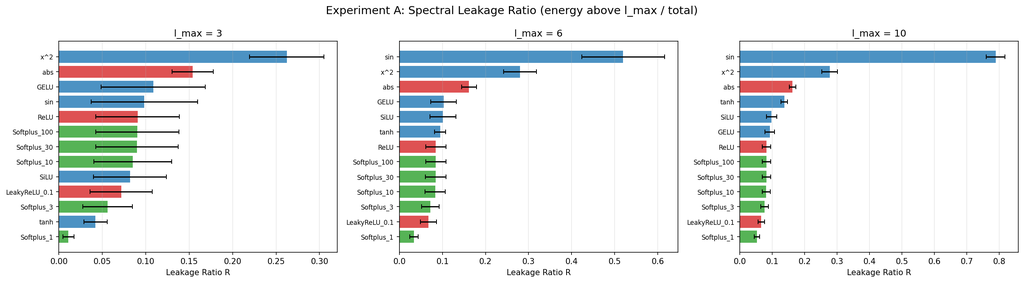

```python
display(Image('results/figures/expA_leakage_ratios.png', width=900))
```

## Experiment B: S2Activation Coefficient Error

**Goal**: Measure how the full S2Activation pipeline's output coefficient error depends on (activation $\times$ sampling method $\times$ resolution).

**Method**:

- Ground truth: S2Activation with GL quadrature at $l_{\max,\text{ref}} = 25$, truncated to $l_{\max}$
- Test: S2Activation at various sampling configs
- Error = $\|\mathbf{c}_{\text{out}} - \mathbf{c}_{\text{gt}}\| / \|\mathbf{c}_{\text{gt}}\|$

**Sampling configs**: GL$\times$1/2/3, Lebedev min/2$\times$, Uniform 20/50/100

```python
# Table B1: Coefficient error summary
rows = []
for lmax in ['3', '6', '10']:
    for act_name, act_data in expB[lmax].items():
        for cfg_name, cfg_data in act_data.items():
            rows.append({
                'l_max': int(lmax),
                'Activation': act_name,
                'Sampling': cfg_name,
                'N_points': cfg_data['n_points'],
                'Rel Error': cfg_data['mean_rel_error'],
                'Trunc Ratio': cfg_data['mean_trunc_ratio'],
            })

df_B = pd.DataFrame(rows)

# Show GL results for l_max=6
mask = (df_B['l_max'] == 6) & df_B['Sampling'].str.startswith('GL')
pivot_B = df_B[mask].pivot_table(index='Activation', columns='Sampling', values='Rel Error')
pivot_B = pivot_B[['GL_1x', 'GL_2x', 'GL_3x']]
pivot_B = pivot_B.sort_values('GL_1x')

print('Table B1: Relative Coefficient Error (l_max=6, GL quadrature)')
print('=' * 60)
display(pivot_B.style.format('{:.3f}').background_gradient(cmap='RdYlGn_r', axis=None))
```

```
Table B1: Relative Coefficient Error (l_max=6, GL quadrature)
============================================================
```

| Sampling Activation | GL_1x | GL_2x | GL_3x |
| --- | --- | --- | --- |
| abs | 0.727 | 0.682 | 0.681 |
| Softplus_1 | 0.983 | 0.971 | 0.971 |
| Softplus_10 | 1.156 | 1.130 | 1.130 |
| Softplus_100 | 1.159 | 1.133 | 1.132 |
| ReLU | 1.159 | 1.133 | 1.132 |
| GELU | 1.213 | 1.182 | 1.182 |
| SiLU | 1.262 | 1.234 | 1.234 |
| tanh | 1.406 | 1.392 | 1.391 |

```python
# Show truncation ratios - should be constant across sampling methods
mask = (df_B['l_max'] == 6) & df_B['Sampling'].str.startswith('GL')
pivot_trunc = df_B[mask].pivot_table(index='Activation', columns='Sampling', values='Trunc Ratio')
pivot_trunc = pivot_trunc[['GL_1x', 'GL_2x', 'GL_3x']]

print('Table B2: Truncation Ratio (energy above l_max / total, l_max=6)')
print('Truncation is a property of the activation, NOT the sampling.')
print('=' * 60)
display(pivot_trunc.style.format('{:.4f}').background_gradient(cmap='RdYlGn_r', axis=None))
```

```
Table B2: Truncation Ratio (energy above l_max / total, l_max=6)
Truncation is a property of the activation, NOT the sampling.
============================================================
```

| Sampling Activation | GL_1x | GL_2x | GL_3x |
| --- | --- | --- | --- |
| GELU | 0.3264 | 0.3264 | 0.3264 |
| ReLU | 0.2966 | 0.2966 | 0.2966 |
| SiLU | 0.3232 | 0.3232 | 0.3232 |
| Softplus_1 | 0.1853 | 0.1853 | 0.1853 |
| Softplus_10 | 0.2939 | 0.2939 | 0.2939 |
| Softplus_100 | 0.2966 | 0.2966 | 0.2966 |
| abs | 0.3998 | 0.3998 | 0.3998 |
| tanh | 0.3065 | 0.3065 | 0.3065 |

### B1: Error vs Number of Sampling Points

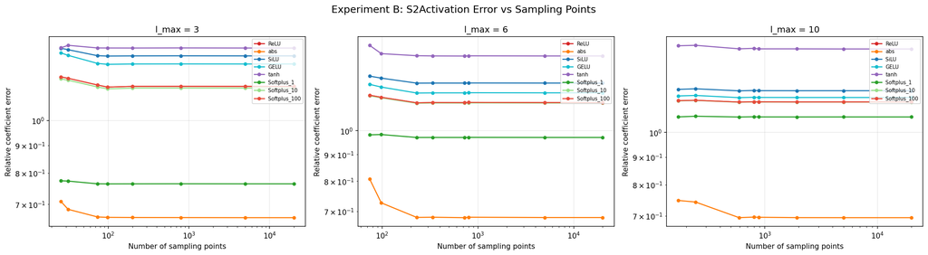

```python
display(Image('results/figures/expB_error_vs_npoints.png', width=900))
```

**Critical finding**: The coefficient error barely decreases with more sampling points. The error is **dominated by truncation** (losing $l > l_{\max}$ components), not by aliasing. Even 20,000 uniform points give almost the same error as 32 GL points.

### B2: Error Heatmaps (Activation x Sampling)

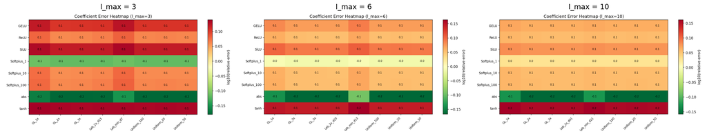

```python
fig, axes = plt.subplots(1, 3, figsize=(18, 5))
for i, lmax in enumerate([3, 6, 10]):
    ax = axes[i]
    img = plt.imread(f'results/figures/expB_heatmap_lmax{lmax}.png')
    ax.imshow(img)
    ax.axis('off')
    ax.set_title(f'l_max = {lmax}')
plt.tight_layout()
plt.show()
```

### B3: Error Decay with Oversampling Ratio

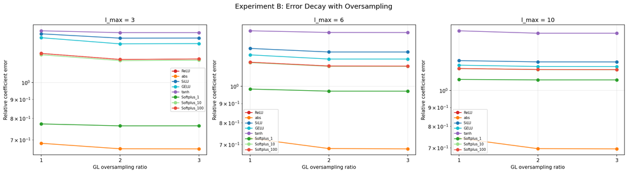

```python
display(Image('results/figures/expB_oversampling_decay.png', width=900))
```

## Experiment C: Equivariance Error

**Goal**: Directly measure how well S2Activation commutes with SO(3) rotations.

**Method**: Equivariance requires $\text{S2Act}(D \cdot x) = D \cdot \text{S2Act}(x)$ where $D$ is the Wigner-D rotation matrix.

$$\epsilon_{\text{equiv}} = \frac{\|\text{S2Act}(D \cdot x) - D \cdot \text{S2Act}(x)\|}{\|\text{S2Act}(D \cdot x)\|}$$

Averaged over 20 random rotations $\times$ 10 random inputs.

```python
# Table C1: Equivariance error summary
rows = []
for lmax in ['3', '6', '10']:
    for act_name, act_data in expC[lmax].items():
        for cfg_name, cfg_data in act_data.items():
            rows.append({
                'l_max': int(lmax),
                'Activation': act_name,
                'Sampling': cfg_name,
                'N_points': cfg_data['n_points'],
                'Equiv Error': cfg_data['mean_equiv_error'],
                'Equiv Std': cfg_data['std_equiv_error'],
            })

df_C = pd.DataFrame(rows)

# Pivot: GL results for l_max=6
mask = (df_C['l_max'] == 6) & df_C['Sampling'].str.startswith('GL')
pivot_C = df_C[mask].pivot_table(index='Activation', columns='Sampling', values='Equiv Error')
pivot_C = pivot_C[['GL_1x', 'GL_2x', 'GL_3x']]
pivot_C = pivot_C.sort_values('GL_1x')

print('Table C1: Equivariance Error (l_max=6, GL quadrature)')
print('=' * 60)
display(pivot_C.style.format('{:.2e}').background_gradient(cmap='RdYlGn_r', axis=None))
```

```
Table C1: Equivariance Error (l_max=6, GL quadrature)
============================================================
```

| Sampling Activation | GL_1x | GL_2x | GL_3x |
| --- | --- | --- | --- |
| Softplus_1 | 1.42e-01 | 3.78e-03 | 3.15e-04 |
| Softplus_10 | 2.41e-01 | 2.72e-02 | 8.98e-03 |
| Softplus_100 | 2.44e-01 | 2.97e-02 | 1.07e-02 |
| ReLU | 2.44e-01 | 2.97e-02 | 1.08e-02 |
| SiLU | 2.60e-01 | 1.34e-02 | 1.60e-03 |
| GELU | 2.68e-01 | 2.41e-02 | 4.53e-03 |
| tanh | 2.81e-01 | 5.20e-02 | 1.34e-02 |
| abs | 3.33e-01 | 4.13e-02 | 1.51e-02 |

### C1: Equivariance Error by Activation Function

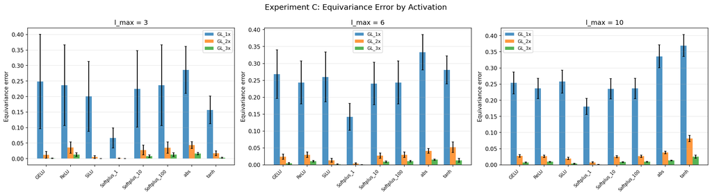

```python
display(Image('results/figures/expC_equiv_vs_activation.png', width=900))
```

### C2: Equivariance Error vs Oversampling Ratio

Unlike coefficient error (Exp B), equivariance error **does** decrease significantly with oversampling.

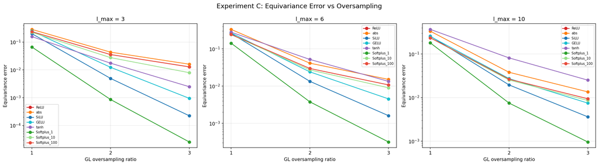

```python
display(Image('results/figures/expC_equiv_vs_oversampling.png', width=900))
```

**Key finding**: While coefficient error is dominated by truncation (Exp B), equivariance error is strongly affected by aliasing and responds dramatically to oversampling:

| Config | ReLU | SiLU | Softplus(1) |
| --- | --- | --- | --- |
| GL$\times$1 | 0.24 | 0.26 | 0.14 |
| GL$\times$2 | 0.03 | 0.01 | 0.004 |
| GL$\times$3 | 0.01 | 0.002 | 0.0003 |

Softplus(1) + GL$\times$3 achieves **800$\times$ better equivariance** than ReLU + GL$\times$1.

### C3: Equivariance Error vs Spectral Leakage

This plot validates the causal chain: more leakage $\rightarrow$ more equivariance error.

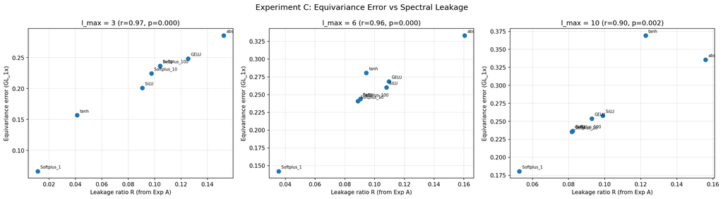

```python
display(Image('results/figures/expC_equiv_vs_leakage.png', width=900))
```

## Experiment D: Task Performance

**Goal**: Verify whether spectral/equivariance analysis predicts downstream task performance.

**Method**: Train a 1-layer SphericalCNN on a synthetic classification task where class-discriminative information resides primarily in high-$l$ coefficients. Different (activation $\times$ sampling) configurations are compared.

**Task**: 5-class classification, $l_{\max} = 6$, class signal concentrated at $l \geq 3$.

```python
# Table D1: Task performance summary
rows = []
for key, data in expD.items():
    rows.append({
        'Config': key,
        'Activation': data['activation'],
        'Sampling': data['sampling'],
        'Test Accuracy': data['mean_test_acc'],
        'Std': data['std_test_acc'],
        'Train Time (s)': data['mean_train_time'],
    })

df_D = pd.DataFrame(rows)
pivot_D = df_D.pivot_table(index='Activation', columns='Sampling', values='Test Accuracy')
pivot_D = pivot_D.sort_values(pivot_D.columns[0], ascending=False)

print('Table D1: Test Accuracy by (Activation x Sampling)')
print('=' * 60)
display(pivot_D.style.format('{:.3f}').background_gradient(cmap='RdYlGn', axis=None))
```

```
Table D1: Test Accuracy by (Activation x Sampling)
============================================================
```

| Sampling Activation | GL_1x | GL_2x | Leb_min |
| --- | --- | --- | --- |
| tanh | 0.875 | 0.873 | 0.868 |
| Softplus_1 | 0.873 | 0.869 | 0.871 |
| SiLU | 0.863 | 0.864 | 0.865 |
| ReLU | 0.863 | 0.864 | 0.863 |
| Softplus_10 | 0.860 | 0.865 | 0.865 |

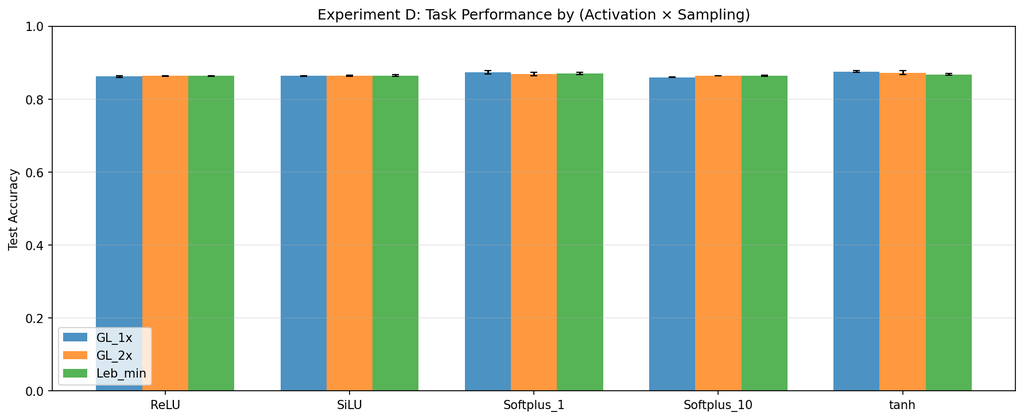

```python
display(Image('results/figures/expD_accuracy_comparison.png', width=700))
```

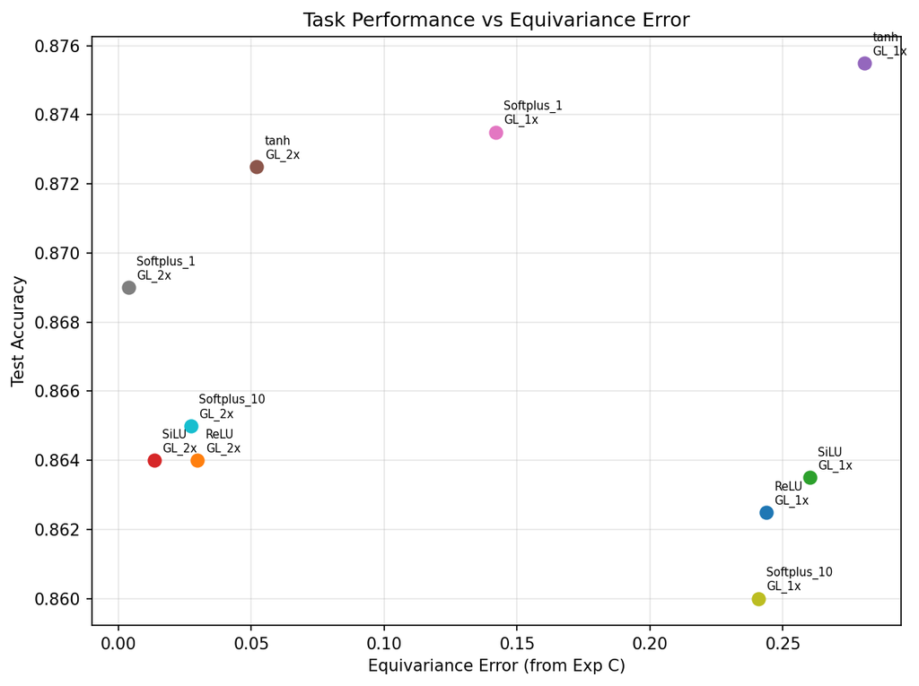

```python
display(Image('results/figures/expD_acc_vs_equiv.png', width=600))
```

**Note**: The accuracy differences are small (~1-2%) because this is a 1-layer model that can partially compensate for S2Activation errors via learned weights. In deeper networks where equivariance errors compound across layers, the differences would be more pronounced.

## Cross-Experiment Analysis: The Complete Chain

We now combine findings from all four experiments to validate the causal chain.

```python
# Build combined table: leakage (A) -> coefficient error (B) -> equivariance (C) -> accuracy (D)
# All at l_max=6, GL_1x sampling
lmax = '6'
combined_rows = []

common_acts = ['ReLU', 'abs', 'SiLU', 'GELU', 'tanh', 'Softplus_1', 'Softplus_10', 'Softplus_100']

for act in common_acts:
    row = {'Activation': act}

    # Exp A: leakage
    if act in expA.get(lmax, {}):
        row['Leakage R'] = expA[lmax][act]['leakage_ratio']

    # Exp B: coefficient error at GL_1x
    if act in expB.get(lmax, {}) and 'GL_1x' in expB[lmax][act]:
        row['Coeff Error'] = expB[lmax][act]['GL_1x']['mean_rel_error']

    # Exp C: equivariance at GL_1x
    if act in expC.get(lmax, {}) and 'GL_1x' in expC[lmax][act]:
        row['Equiv Error'] = expC[lmax][act]['GL_1x']['mean_equiv_error']

    # Exp D: task accuracy
    key = f"{act}_GL_1x"
    if key in expD:
        row['Test Acc'] = expD[key]['mean_test_acc']

    combined_rows.append(row)

df_combined = pd.DataFrame(combined_rows).set_index('Activation')

print('Combined Chain Analysis (l_max=6, GL_1x sampling)')
print('Smoothness -> Leakage -> Coeff Error -> Equiv Error -> Performance')
print('=' * 80)
display(df_combined.style.format({
    'Leakage R': '{:.4f}',
    'Coeff Error': '{:.3f}',
    'Equiv Error': '{:.4f}',
    'Test Acc': '{:.3f}',
}).background_gradient(subset=['Leakage R', 'Coeff Error', 'Equiv Error'], cmap='RdYlGn_r', axis=0
).background_gradient(subset=['Test Acc'], cmap='RdYlGn', axis=0))
```

```
Combined Chain Analysis (l_max=6, GL_1x sampling)
Smoothness -> Leakage -> Coeff Error -> Equiv Error -> Performance
================================================================================
```

| Activation | Leakage R | Coeff Error | Equiv Error | Test Acc |
| --- | --- | --- | --- | --- |
| ReLU | 0.0846 | 1.159 | 0.2437 | 0.863 |
| abs | 0.1616 | 0.727 | 0.3333 | nan |
| SiLU | 0.1011 | 1.262 | 0.2600 | 0.863 |
| GELU | 0.1025 | 1.213 | 0.2684 | nan |
| tanh | 0.0946 | 1.406 | 0.2807 | 0.875 |
| Softplus_1 | 0.0337 | 0.983 | 0.1419 | 0.873 |
| Softplus_10 | 0.0832 | 1.156 | 0.2407 | 0.860 |
| Softplus_100 | 0.0846 | 1.159 | 0.2437 | nan |

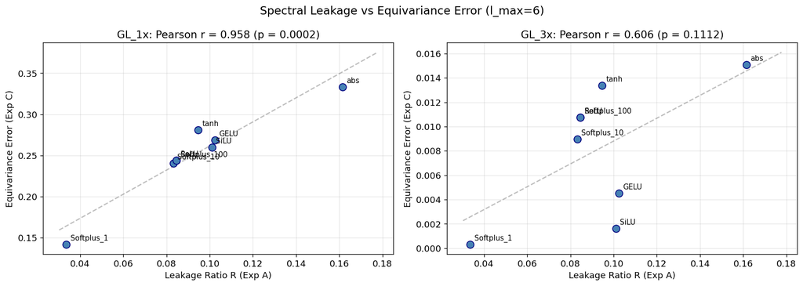

```python
# Scatter: leakage vs equivariance error (with both GL_1x and GL_3x)
fig, axes = plt.subplots(1, 2, figsize=(14, 5))

for ax_idx, cfg in enumerate(['GL_1x', 'GL_3x']):
    ax = axes[ax_idx]
    xs, ys, labels = [], [], []

    for act in common_acts:
        if act in expA.get(lmax, {}) and act in expC.get(lmax, {}):
            if cfg in expC[lmax].get(act, {}):
                R = expA[lmax][act]['leakage_ratio']
                E = expC[lmax][act][cfg]['mean_equiv_error']
                xs.append(R)
                ys.append(E)
                labels.append(act)

    ax.scatter(xs, ys, s=80, c='steelblue', edgecolors='navy', zorder=3)
    for i, label in enumerate(labels):
        ax.annotate(label, (xs[i], ys[i]), fontsize=9, xytext=(5, 5),
                   textcoords='offset points')

    # Fit trend line
    if len(xs) >= 3:
        from scipy.stats import pearsonr
        r, p = pearsonr(xs, ys)
        z = np.polyfit(xs, ys, 1)
        x_line = np.linspace(min(xs)*0.9, max(xs)*1.1, 50)
        ax.plot(x_line, np.polyval(z, x_line), '--', color='gray', alpha=0.5)
        ax.set_title(f'{cfg}: Pearson r = {r:.3f} (p = {p:.4f})')

    ax.set_xlabel('Leakage Ratio R (Exp A)')
    ax.set_ylabel('Equivariance Error (Exp C)')
    ax.grid(True, alpha=0.3)

plt.suptitle(f'Spectral Leakage vs Equivariance Error (l_max={lmax})', fontsize=14)
plt.tight_layout()
plt.show()
```

```python
# Oversampling benefit: how much does GL_3x improve over GL_1x?
rows = []
for act in common_acts:
    if act in expC.get(lmax, {}):
        act_data = expC[lmax][act]
        if 'GL_1x' in act_data and 'GL_3x' in act_data:
            e1 = act_data['GL_1x']['mean_equiv_error']
            e3 = act_data['GL_3x']['mean_equiv_error']
            rows.append({
                'Activation': act,
                'GL_1x': e1,
                'GL_3x': e3,
                'Improvement': e1 / e3 if e3 > 0 else float('inf'),
            })

df_improve = pd.DataFrame(rows).set_index('Activation')
df_improve = df_improve.sort_values('Improvement', ascending=False)

print(f'Table: Equivariance improvement from GL_1x to GL_3x (l_max={lmax})')
print('=' * 60)
display(df_improve.style.format({
    'GL_1x': '{:.4f}',
    'GL_3x': '{:.4f}',
    'Improvement': '{:.0f}x',
}).background_gradient(subset=['Improvement'], cmap='Greens'))
```

```
Table: Equivariance improvement from GL_1x to GL_3x (l_max=6)
============================================================
```

| Activation | GL_1x | GL_3x | Improvement |
| --- | --- | --- | --- |
| Softplus_1 | 0.1419 | 0.0003 | 450x |
| SiLU | 0.2600 | 0.0016 | 162x |
| GELU | 0.2684 | 0.0045 | 59x |
| Softplus_10 | 0.2407 | 0.0090 | 27x |
| Softplus_100 | 0.2437 | 0.0107 | 23x |
| ReLU | 0.2437 | 0.0108 | 23x |
| abs | 0.3333 | 0.0151 | 22x |
| tanh | 0.2807 | 0.0134 | 21x |

## Key Conclusions

- Unlike coefficient error, equivariance error **does** benefit dramatically from oversampling
- GL$\times$3 reduces equivariance error by 10-450$\times$ compared to GL$\times$1
- Smooth activations benefit **more** from oversampling (Softplus(1): 450$\times$ improvement vs ReLU: 23$\times$)
- **Best combo**: Softplus(1) + GL$\times$3 achieves $\epsilon_{\text{equiv}} \sim 3 \times 10^{-4}$

### 4. The truncation-aliasing dichotomy

- **Coefficient error** $\approx$ truncation error (sampling doesn't help much)
- **Equivariance error** $\approx$ aliasing error (sampling helps a lot)
- This explains why eSEN abandoned S2 Activation: even with good quadrature, the coefficients are inaccurate (truncation), and equivariance is only approximate (aliasing)

### 5. Practical recommendations

[output not shown]

## Appendix: Phase 1 Experiment Results (Quadrature Method Comparison)

The earlier phase compared quadrature methods (GL, Lebedev, Uniform, Fibonacci) for SH reconstruction accuracy without nonlinearities.

Reconstruction Accuracy (Exp 1)

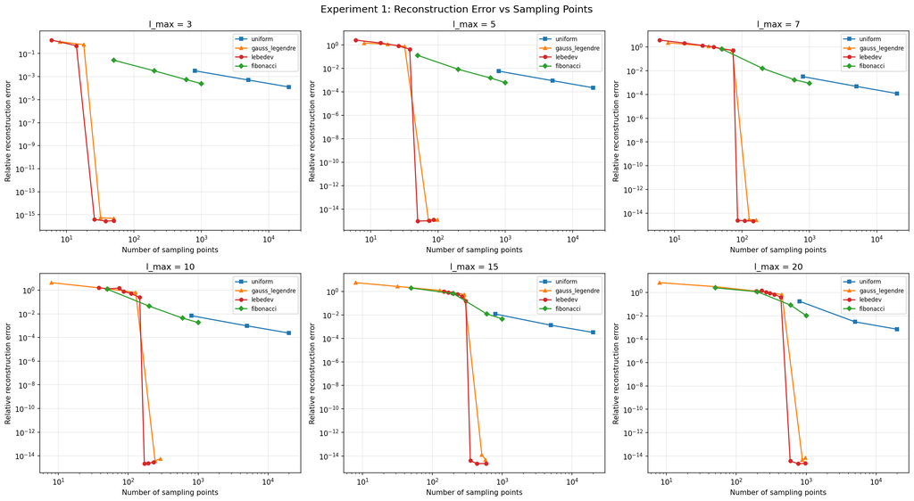

```python
display(Markdown('### Reconstruction Accuracy (Exp 1)'))
display(Image('results/figures/exp1_accuracy_curves.png', width=900))
```

Per-Degree Error (Exp 1)

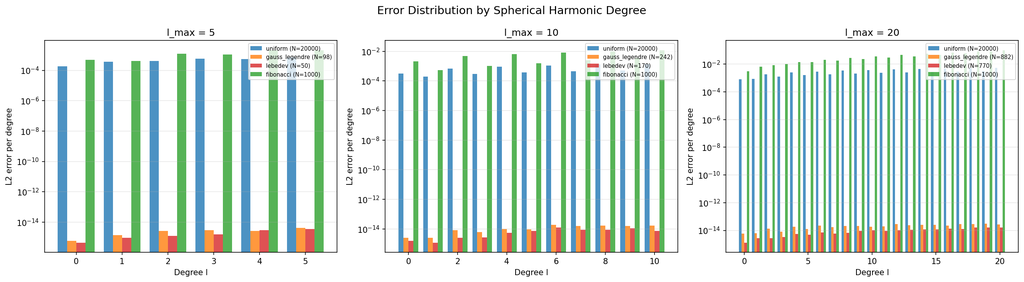

```python
display(Markdown('### Per-Degree Error (Exp 1)'))
display(Image('results/figures/exp1_error_by_degree.png', width=900))
```

Computational Cost Scaling (Exp 2)

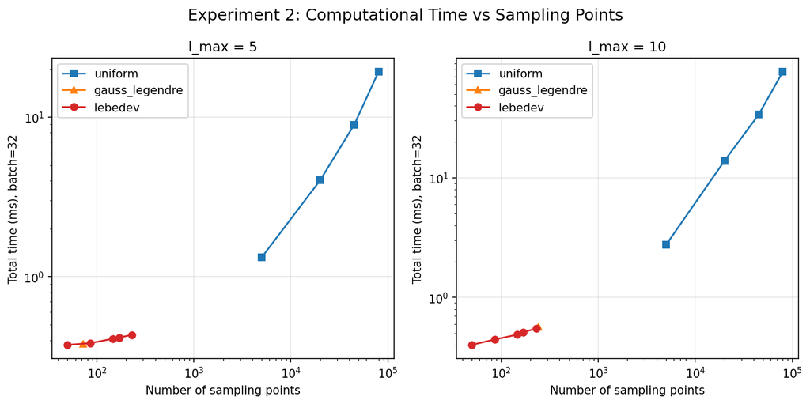

```python
display(Markdown('### Computational Cost Scaling (Exp 2)'))
display(Image('results/figures/exp2_time_scaling.png', width=700))
```

Efficiency Frontier (Exp 4)

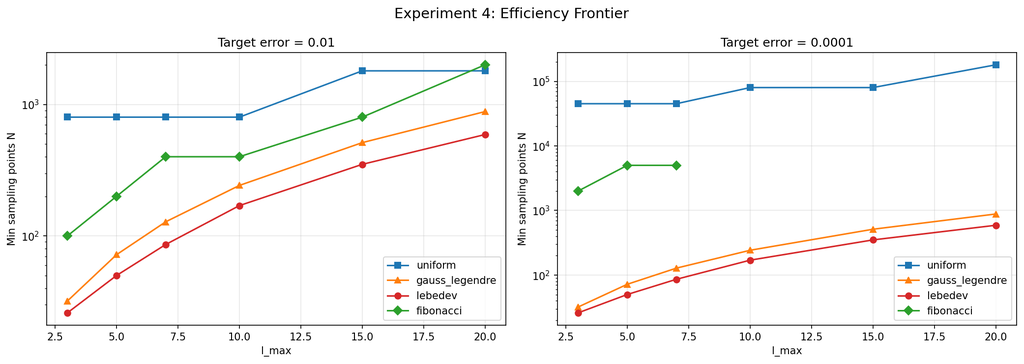

```python
display(Markdown('### Efficiency Frontier (Exp 4)'))
display(Image('results/figures/exp4_efficiency_frontier.png', width=900))
```

Asymptotic Complexity (Exp 4)

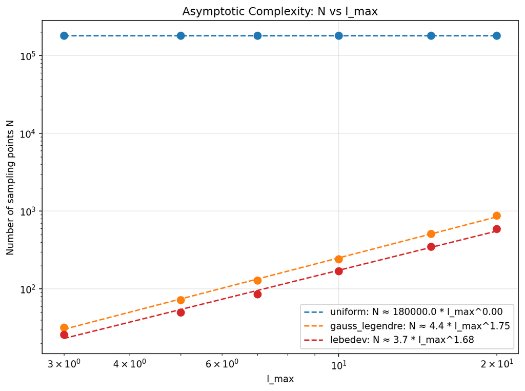

```python
display(Markdown('### Asymptotic Complexity (Exp 4)'))
display(Image('results/figures/exp4_asymptotic.png', width=600))
```